# Employment and Entrepreneurial Activity: An Instrumental Variables Approach

Final Project

Author

Affiliation

Mehrdad Alikhani

Old Dominion University

## Introduction

Online crowdfunding platforms such as Kickstarter have become an important channel for early-stage entrepreneurial activity in the United States. Thousands of creators now use these platforms to test ideas, raise seed capital, and build early relationships with customers without relying on banks or venture capital. At the same time, local labor markets have experienced substantial variation in employment growth across states and industries. These changes in employment affect households’ income, risk tolerance, and expectations about future economic conditions, all of which could shape both the supply of new projects on crowdfunding platforms and the willingness of backers to invest in them.

A large literature in economics and entrepreneurship studies how local labor-market conditions influence self-employment and business formation. One strand emphasizes a “push” mechanism, where weak labor markets and high unemployment encourage individuals to pursue self-employment as a fallback option. Another strand highlights “pull” forces: strong labor markets raise incomes and local demand, potentially creating more attractive opportunities for new ventures. A separate literature on crowdfunding documents that geography, social networks, and local information frictions matter for both the volume and success of crowdfunding campaigns. However, we know relatively little about how state-level labor-market dynamics translate into entrepreneurial activity on crowdfunding platforms.

The analysis combines Kickstarter campaign data with state-by-industry employment records from the BLS Current Employment Statistics (CES) to construct a panel of state-year observations. I estimate fixed-effects models that control for time-invariant differences across states and nationwide trends over time. I then compare naïve OLS estimates, reduced-form regressions of crowdfunding outcomes on the Bartik instrument, and instrumental-variables specifications that treat employment growth as endogenous.

This study contributes to the literature in two ways. First, it brings together data on online crowdfunding and local labor-market conditions to provide new evidence on how macroeconomic shocks shape entrepreneurial activity. Second, by using a Bartik identification strategy, the project aims to move beyond simple correlations and provide a causal estimate of how exogenous changes in employment affect the growth and success of crowdfunding campaigns. The findings speak to policymakers interested in entrepreneurship support programs and to platforms that rely on local economic conditions to sustain new venture creation.

## Literature Review

Research on crowdfunding shows that entrepreneurial activity and funding outcomes on online platforms are shaped by geography, social networks, and local information frictions. Using data from an early online crowdfunding platform, Local and distant funders behave differently: nearby backers rely more on offline social ties and private information, while distant investors respond more to publicly observable funding dynamics and platform signals (Agrawal et al., 2015). Crowdfunding success is systematically related to project quality, founder characteristics, and geography, with regional clusters and local social capital associated with higher funding rates (Mollick, 2014). Together, these studies highlight that local context matters for crowdfunding outcomes, even in an online setting (Agrawal et al., 2015; Mollick, 2014).

A separate but related literature examines how local labor-market conditions affect entrepreneurship. Evidence from Germany shows that entrepreneurial entry is systematically related to the business cycle and local unemployment, with higher unemployment associated with more entry in some sectors (“unemployment push”) but also with weaker demand in others (“demand pull”) (Fritsch et al., 2015). More recent work develops a micro-founded model in which unemployed individuals are more likely to start firms, but those firms tend to be smaller and fail more often, implying that labor-market conditions shape both the quantity and quality of entrepreneurial activity (da Fonseca, 2022).

## Data Description

### Part 1: Kickstarter Excel Data

The dataset used in this project comes from ICPSR 38050: Kickstarter Data, Global, 2016–2023. It contains over 330,000 projects launched worldwide across major categories such as Film & Video, Games, Technology, Design, and Art. Each record includes project-level information on category and subcategory, launch and deadline dates, funding goals and pledged amounts, backer counts, geographic identifiers, and project outcomes (successful, failed, canceled, or suspended). To protect confidentiality, ICPSR has masked certain identifying fields (e.g., project names and URLs) and excluded free-text descriptions. Monetary values are available in both original currency and USD, enabling consistent comparisons across regions and time.

```r
library(readxl)
library(dplyr)
library(ggplot2)
library(skimr)
library(knitr)
library(kableExtra)
library(tidyr)
library(scales)
library(fixest)
library(modelsummary)

file_path <- "38050-0001-Data.xlsx"

df_ks <- read_excel(file_path, .name_repair = "unique")
```

#### 1-1: Projects per Year by Region (Non-US, US, Total)

This subsection summarizes the evolution of Kickstarter activity over time by distinguishing between U.S. and non-U.S. projects. Using launch dates to extract calendar years, projects are counted separately for U.S. and international creators and then combined to form a total annual series.

```r
df_ks$LAUNCHED_DATE <- suppressWarnings(as.Date(df_ks$LAUNCHED_DATE, format = "%m/%d/%y"))

# Create YEAR variable
df_ks$YEAR <- as.integer(format(df_ks$LAUNCHED_DATE, "%Y"))

# Create US vs Non-US classification
state_map <- setNames(state.name, state.abb)
df_ks$US_STATE <- state_map[df_ks$PROJECT_PAGE_LOCATION_STATE]
df_ks$IS_US <- ifelse(!is.na(df_ks$US_STATE), "US", "Non-US")

year_summary <- df_ks %>%
  filter(!is.na(YEAR), YEAR >= 2016, YEAR <= 2023) %>%
  group_by(YEAR, IS_US) %>%
  summarize(Count = n(), .groups = "drop") %>%
  tidyr::pivot_wider(
    names_from = IS_US,
    values_from = Count,
    values_fill = 0
  ) %>%
  mutate(
    Total = US + `Non-US`,
    YEAR = as.character(YEAR)
  ) %>%
  arrange(YEAR)

total_row <- tibble(
  YEAR = "Total",
  `Non-US` = sum(year_summary$`Non-US`, na.rm = TRUE),
  US = sum(year_summary$US, na.rm = TRUE),
  Total = sum(year_summary$Total, na.rm = TRUE)
)

year_summary_final <- bind_rows(year_summary, total_row)

# Prepare for line chart
year_long <- year_summary %>%
  select(YEAR, `Non-US`, US, Total) %>%
  tidyr::pivot_longer(
    cols = c(`Non-US`, US, Total),
    names_to = "Region",
    values_to = "Count"
  )

# LINE CHART
ggplot(year_long, aes(x = YEAR, y = Count, color = Region, group = Region)) +
  geom_line(size = 1.2) +
  geom_point(size = 2) +
  scale_color_manual(values = c(
    "Non-US" = "red",
    "US" = "blue",
    "Total" = "gray40"
  )) +
  labs(
    title = "Projects per Year by Region (Non-US, US, Total)",
    x = "Year",
    y = "Number of Projects"
  ) +
  theme_minimal() +
  theme(axis.text.x = element_text(angle = 45, hjust = 1))
```

**Plot**

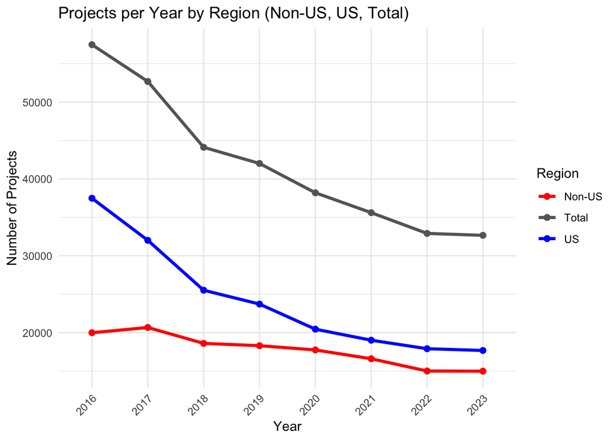

#### 1-2: Success Rates by Year (US vs Non-US)

In this subsection, annual Kickstarter success rates are computed for U.S. and non-U.S. projects. Success is defined as reaching or exceeding the funding goal. After aggregating successful and total projects within each region-year, success rates are calculated and visualized over time. This comparison shows how the likelihood of successful funding has changed across regions and provides descriptive context for understanding differences in project performance beyond simple project counts.

```r
df_ks$success_flag <- ifelse(df_ks$STATE == "successful", 1, 0)

temp <- df_ks %>%
  filter(!is.na(YEAR), YEAR >= 2016, YEAR <= 2023) %>%
  group_by(YEAR, IS_US) %>%
  summarize(
    total = n(),
    successful = sum(success_flag),
    .groups = "drop"
  )

success_year <- temp %>%
  tidyr::pivot_wider(
    names_from = IS_US,
    values_from = c(total, successful),
    names_glue = "{.value}_{IS_US}",
    values_fill = 0
  )

if (!"total_US" %in% names(success_year)) success_year$total_US <- 0
if (!"total_Non-US" %in% names(success_year)) success_year$`total_Non-US` <- 0
if (!"successful_US" %in% names(success_year)) success_year$successful_US <- 0
if (!"successful_Non-US" %in% names(success_year)) success_year$`successful_Non-US` <- 0

success_year <- success_year %>%
  mutate(
    YEAR = as.character(YEAR),
    `Non-US` = `total_Non-US`,
    US = total_US,
    Total = `Non-US` + US,
    `Success Rate Non-US` = ifelse(`Non-US` > 0, `successful_Non-US` / `Non-US`, NA),
    `Success Rate US` = ifelse(US > 0, successful_US / US, NA),
    `Success Rate Total` = (successful_US + `successful_Non-US`) / Total
  ) %>%
  select(
    YEAR,
    `Non-US`, US, Total,
    `Success Rate Non-US`,
    `Success Rate US`,
    `Success Rate Total`
  ) %>%
  arrange(YEAR)

success_long <- success_year %>%
  select(
    YEAR,
    `Success Rate Non-US`,
    `Success Rate US`,
    `Success Rate Total`
  ) %>%
  pivot_longer(
    cols = starts_with("Success Rate"),
    names_to = "Region",
    values_to = "Rate"
  )

# Plot
ggplot(success_long, aes(x = YEAR, y = Rate, color = Region, group = Region)) +
  geom_line(size = 1.2) +
  geom_point(size = 2) +
  scale_y_continuous(labels = scales::percent) +
  scale_color_manual(values = c(
    "Success Rate Non-US" = "red",
    "Success Rate US" = "blue",
    "Success Rate Total" = "gray40"
  )) +
  labs(
    title = "Success Rates by Year (Non-US, US, Total)",
    x = "Year",
    y = "Success Rate"
  ) +
  theme_minimal() +
  theme(axis.text.x = element_text(angle = 45, hjust = 1))
```

**Plot**

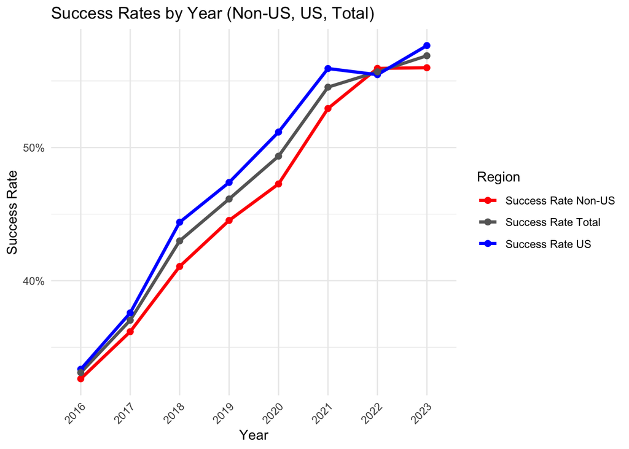

#### 1-3. Success Rate by U.S. State

This subsection focuses on geographic variation within the United States. By mapping state abbreviations to full state names and aggregating projects at the state level, we compute each state’s overall success rate across all years. The accompanying scatter plot relates total project volume to success rates.

```r
state_map <- setNames(state.name, state.abb)

df_ks$STATE_NAME <- state_map[df_ks$PROJECT_PAGE_LOCATION_STATE]

# Keep U.S. states only
df_us <- df_ks %>% filter(!is.na(STATE_NAME))

state_rate_us <- df_us %>%
  group_by(STATE_NAME) %>%
  summarize(
    Total = n(),
    Successful = sum(success_flag),
    Success_Rate = Successful / Total,
    .groups = "drop"
  ) %>%
  arrange(desc(Total))

# States to label on the plot only
label_states <- c(
  "California", "New York", "Texas", "Florida", "South Dakota",
  "Georgia", "Massachusetts", "Vermont", "Oregon", "Washington",
  "Virginia", "Mississippi", "Alabama"
)

state_rate_us <- state_rate_us %>%
  mutate(Label = ifelse(STATE_NAME %in% label_states, STATE_NAME, ""))


#Plot
ggplot(state_rate_us, aes(x = Total, y = Success_Rate)) +
  geom_point(color = "steelblue", size = 3) +
  geom_text(aes(label = Label), vjust = -0.7, size = 3.3) +
  scale_x_continuous(limits = c(-10000, max(state_rate_us$Total) * 1.05)) +
  scale_y_continuous(
    limits = c(0.20, 0.65),   # <<--- Start from 20%
    labels = scales::percent
  ) +
  labs(
    title = "U.S. States: Total Projects vs. Success Rate",
    x = "Total Projects",
    y = "Success Rate"
  ) +
  theme_minimal()
```

**Plot**

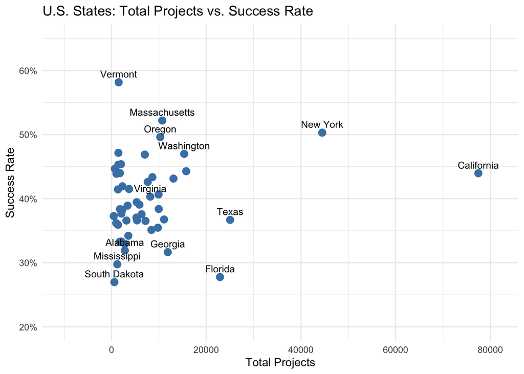

### Part 2: U.S. Employment Data (BLS CES)

This section introduces the second major dataset used in the project: U.S. state–industry employment from the BLS Current Employment Statistics (CES) program. The CES dataset provides monthly employment counts for all states and major industries between 2016 and 2023. These data allow us to construct state–year employment totals and compute baseline industry shares.

#### 2-1: Introduction to the Employment Dataset

The dataset includes:

- Monthly employment levels for each state × industry
- State and industry identifiers
- Coverage of nine major CES super-sectors

These data allow us to quantify differences in labor-market size, industry composition, and year-to-year fluctuations across states. Combined with the Kickstarter dataset, this enables analysis of whether regions experiencing stronger labor-market growth tend to have higher crowdfunding activity or success rates.

#### 2-2: Load and Clean the Employment Data

The raw CES file contains monthly employment counts for each state × industry × month. To make the data compatible with the Kickstarter panel, I reshape the dataset into an annual format. For each state–industry pair, I compute the average monthly employment within each calendar year, producing a state–industry–year panel from 2016 to 2023.

```r
library(stringr)

# Load file
df <- read_excel("bls_employment_state_2010_2024.xlsx")

month_cols <- grep("^[A-Za-z]{3}[0-9]{4}$", names(df), value = TRUE)

df_long <- df %>%
  pivot_longer(
    cols = all_of(month_cols),
    names_to = "month_year",
    values_to = "value"
  ) %>%
  mutate(
    Year = as.numeric(str_sub(month_year, -4, -1))
  )

df_yearly <- df_long %>%
  group_by(state_name, industry, Year) %>%
  summarize(value = mean(value, na.rm = TRUE), .groups = "drop") %>%
  filter(Year >= 2016, Year <= 2023)

df_yearly %>%
  summarise(
    `Number of States`      = n_distinct(state_name),
    `Number of Industries`  = n_distinct(industry),
    `Number of Years`       = n_distinct(Year),
    `Minimum Employment (thousands)`    = min(value, na.rm = TRUE),
    `Maximum Employment (thousands)`    = max(value, na.rm = TRUE),
    `Average Employment`    = mean(value, na.rm = TRUE)
  ) %>%
  kbl(
    caption = "Summary of State–Industry Employment Data (2016–2023)",
    digits = 1
  ) %>%
  kable_styling(full_width = FALSE)
```

**Output**

Summary of State–Industry Employment Data (2016–2023)

| Number of States | Number of Industries | Number of Years | Minimum Employment (thousands) | Maximum Employment (thousands) | Average Employment |
| --- | --- | --- | --- | --- | --- |
| 53 | 9 | 8 | 0.2 | 3124.8 | 251.2 |

#### 2-3: National Employment Trends, 2016–2023

This subsection provides a macro-level view of U.S. employment during 2016–2023.

```r
industries <- c(
  "Mining and Logging",
  "Construction",
  "Manufacturing",
  "Trade, Transportation, and Utilities",
  "Information",
  "Professional and Business Services",
  "Leisure and Hospitality",
  "Other Services",
  "Government"
)

# Filter nine industries
df_industry <- df_yearly %>%
  filter(industry %in% industries) %>%
  group_by(industry, Year) %>%
  summarize(avg_emp = mean(value, na.rm = TRUE), .groups = "drop")

# Plot
ggplot(df_industry, aes(x = Year, y = avg_emp, color = industry, group = industry)) +
  geom_line(linewidth = 1.1) +
  geom_point(size = 2) +
  labs(
    title = "Average Employment by Industry (2016–2023)",
    x = "Year",
    y = "Average Employees (Thousands)",
    color = " "
  ) +
  theme_minimal(base_size = 11) +
  theme(
    legend.position = "bottom",
    legend.title = element_text(size = 12),
    legend.text = element_text(size = 8),
    legend.box = "horizontal",
    legend.key.width = unit(1.2, "cm"),
    legend.key.height = unit(0.3, "cm")
  ) +
  guides(color = guide_legend(ncol = 3, byrow = TRUE))
```

**Plot**

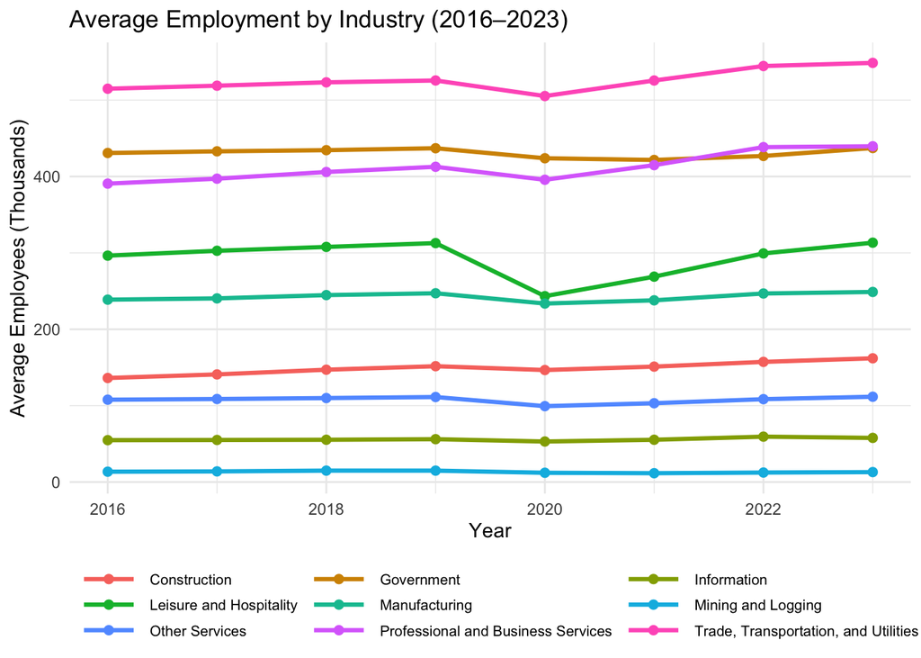

#### Summary Statistics

```r
# 1. Aggregate Kickstarter success rate by state-year
ks_state_year <- df_ks %>%
  filter(!is.na(STATE_NAME), !is.na(YEAR),
         YEAR >= 2016, YEAR <= 2023) %>%
  group_by(STATE_NAME, YEAR) %>%
  summarize(
    total_projects = n(),
    successful = sum(success_flag),
    success_rate = successful / total_projects,
    .groups = "drop"
  ) %>%
  rename(state = STATE_NAME,
         year = YEAR)

# 2. Aggregate employment by state-year
emp_state_year <- df_yearly %>%
  group_by(state_name, Year) %>%
  summarize(
    emp = sum(value, na.rm = TRUE),
    .groups = "drop"
  ) %>%
  rename(state = state_name,
         year = Year)

# 3. Merge Kickstarter and employment data
panel <- ks_state_year %>%
  left_join(emp_state_year, by = c("state", "year"))

# 4–5. Compute percent changes
panel <- panel %>%
  mutate(year = as.integer(year)) %>%   # ensure proper ordering
  group_by(state) %>%
  arrange(year) %>%
  mutate(
    # percent change in employment
    delta_emp = (emp - lag(emp)) / lag(emp),

    # percent change in success rate
    delta_cf  = (success_rate - lag(success_rate)) / lag(success_rate),

    # percent change in number of projects
    delta_projects = (total_projects - lag(total_projects)) / lag(total_projects)
  ) %>%
  ungroup()

# 6. Construct Bartik instrument

# Step 6a: compute baseline industry shares for 2018
baseline_shares <- df_yearly %>%
  filter(Year == 2018) %>%
  group_by(state_name, industry) %>%
  summarise(
    base_emp = sum(value, na.rm = TRUE),
    .groups = "drop"
  ) %>%
  group_by(state_name) %>%
  mutate(
    share_base = base_emp / sum(base_emp, na.rm = TRUE)
  ) %>%
  ungroup()


# Step 6b: compute national industry shocks
nat_shocks <- df_yearly %>%
  filter(Year >= 2016, Year <= 2023) %>%   # ensure same range
  group_by(industry, Year) %>%
  summarize(national_emp = sum(value, na.rm = TRUE), .groups = "drop") %>%  # sum not mean
  group_by(industry) %>%
  arrange(Year) %>%
  mutate(growth_nat = (national_emp - lag(national_emp)) / lag(national_emp)) %>%
  ungroup()


# Step 6c: merge baseline shares with national shocks
bartik_raw <- baseline_shares %>%
  left_join(nat_shocks, by = "industry") %>%
  rename(state = state_name, year = Year)

# Step 6d: collapse to state-year Bartik shock
bartik <- bartik_raw %>%
  group_by(state, year) %>%
  summarize(bartik_iv = sum(share_base * growth_nat, na.rm = TRUE),
            .groups = "drop")

# 7. Merge Bartik into panel
df_panel <- panel %>%
  left_join(bartik, by = c("state", "year"))

# 8. Remove rows with missing Δ variables
df_panel <- df_panel %>%
  filter(!is.na(delta_cf), !is.na(delta_emp), !is.na(bartik_iv))

# 9. Make state and year fixed-effects factors
df_panel <- df_panel %>%
  mutate(
    state = as.factor(state),
    year = as.factor(year)
  )
```

The summary statistics indicate heterogeneity across states. Total project counts vary widely, as indicated by the large standard deviation relative to the mean, while success rates show more modest dispersion. Employment levels also vary substantially across states, reflecting differences in population size and industrial composition. The growth variables (Δsuccess rate, Δemployment, and Δproject counts) exhibit meaningful year-to-year variation, which is essential for identifying the relationship between economic conditions and crowdfunding activity.

**Output**

```{=html}

Unique

Missing Pct.

Mean

SD

Min

Median

Max

Histogram

total_projects

268

0

446.5

669.2

14.0

254.5

5878.0

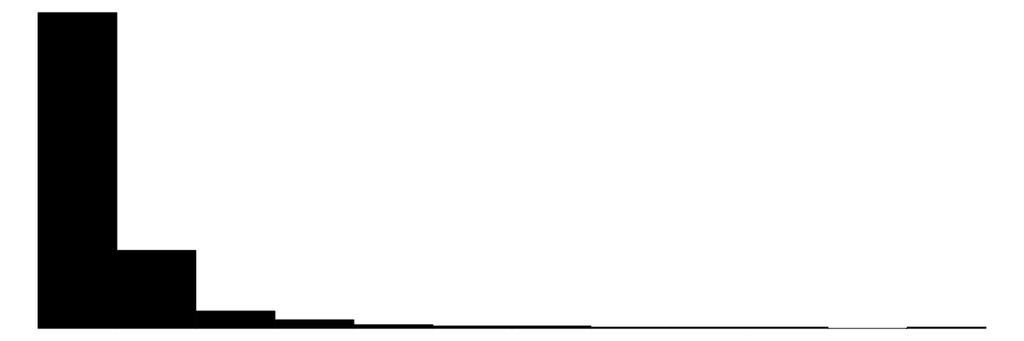

success_rate

330

0

0.5

0.1

0.1

0.5

0.8

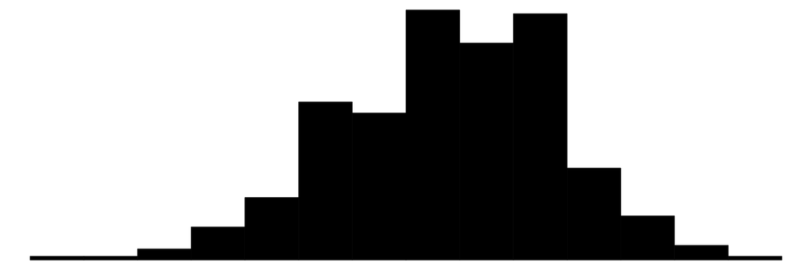

emp

350

0

2315.8

2519.8

214.4

1560.3

13904.0

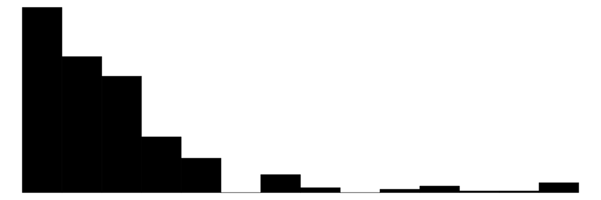

delta_cf

350

0

0.1

0.2

-0.4

0.1

0.9

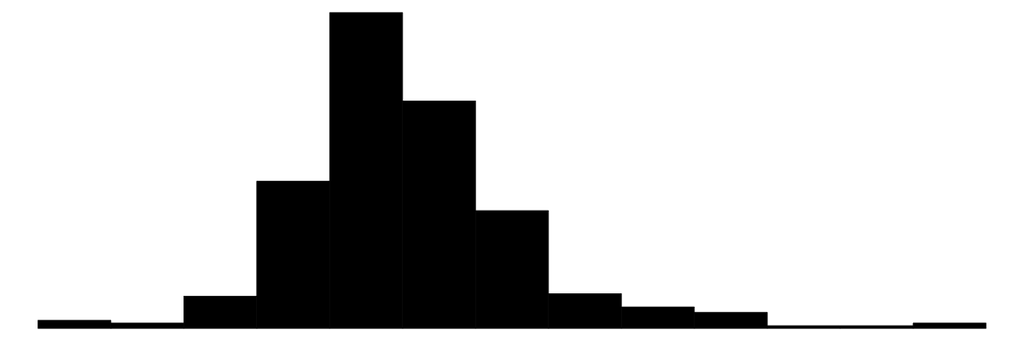

delta_emp

350

0

0.0

0.0

-0.2

0.0

0.1

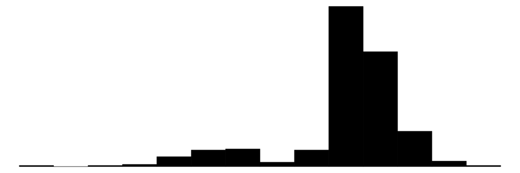

delta_projects

339

0

-0.1

0.2

-0.6

-0.1

1.0

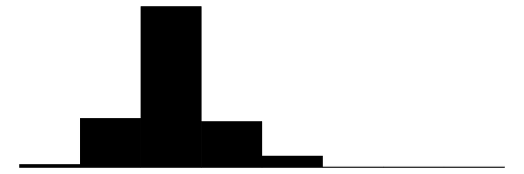

bartik_iv

350

0

0.0

0.0

-0.1

0.0

0.1

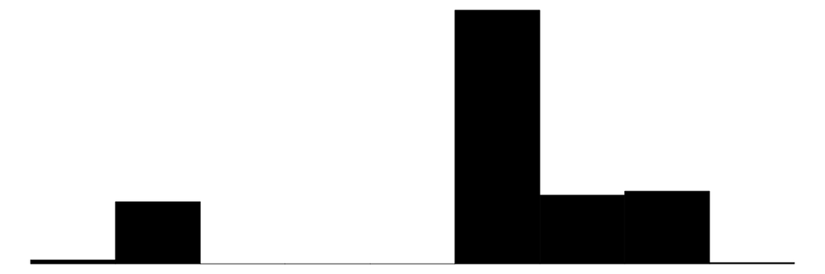

```

```r
vars <- df_panel[, c("total_projects", "success_rate", "emp",
                     "delta_cf", "delta_emp", "delta_projects", "bartik_iv")]

datasummary_skim(vars,
                 title = "Table: Summary Statistics for State–Year Panel")
```

In this state–year panel, total_projects is the number of Kickstarter projects launched in state $s$ in year $t$. success_rate is the share of those projects that reach their funding goal. emp is total state employment constructed from CES data. delta_emp is the percent change in total employment between years $t_1$ and $t$; delta_cf is the percent change in the success rate; and delta_projects is the percent change in the number of projects. bartik_iv is the Bartik (shift–share) instrument, defined as the 2018 state–industry employment shares interacted with national industry-specific employment shocks.

#### Share of state-year observations with zero projects

```r
zero_stats <- ks_state_year %>%
summarise(
N = n(),
zeros = sum(total_projects == 0, na.rm = TRUE),
pct_zero = mean(total_projects == 0, na.rm = TRUE) * 100
)
```

The main estimating equation is:

$$\Delta CF_{s,t} = \beta \, \Delta Emp_{s,t} + \eta_s + \tau_t + \varepsilon_{s,t},$$

Where:

- $s$ indexes states and $t$ indexes years.
- $Emp_{s,t}$ is total state employment from CES.
- $\Delta Emp_{s,t} = \dfrac{Emp_{s,t} - Emp_{s,t-1}}{Emp_{s,t-1}}$ is the **percent change in employment** between years $t-1$ and $t$.
- $CF_{s,t}$ is a Kickstarter outcome: either the state–year success rate or the number of projects.
- $\Delta CF_{s,t}$ is the corresponding **percent change** between years $t-1$ and $t$.
- $\eta_s$ and $\tau_t$ are state and year fixed effects.

Since $\Delta Emp_{s,t}$ may be endogenous, I instrument it using a Bartik term:

$$B_{s,t}
= \sum_k \text{share}^{\text{base}}_{s,k} \cdot g_{k,t},$$

where $\text{share}^{\text{base}}_{s,k}$ is the 2018 employment share of industry $k$ in state $s$, and $g_{k,t}$ is the national industry employment shock. These shares are fixed across time, and the shocks vary across time but are common across states; their interaction produces state-specific predicted shifts in employment growth that are plausibly exogenous.

## Empirical Strategy

The empirical goal is to estimate whether changes in local labor-market conditions influence changes in state-level crowdfunding performance. Because employment growth may be correlated with unobserved state-specific shocks that also affect Kickstarter outcomes, I use a Bartik (shift–share) instrument to isolate plausibly exogenous variation in employment growth.

The empirical IV framework consists of four standard equations:

1. **Naïve (OLS)**
   $$Y_{s,t}
   = \alpha_N + \beta_N D_{s,t} + \gamma_N X_{s,t} + \eta_s + \tau_t + \varepsilon_{s,t}.$$
2. **Reduced Form**
   $$Y_{s,t}
   = \alpha_R + \pi_R Z_{s,t} + \delta_R X_{s,t} + \eta_s + \tau_t + u_{s,t}.$$
3. **First Stage**
   $$D_{s,t}
   = \alpha_F + \pi_F Z_{s,t} + \delta_F X_{s,t} + \eta_s + \tau_t + v_{s,t},$$
   where $\pi_F$ measures the relevance of the instrument. I report the first-stage F-statistic on $Z_{s,t}$.
4. **Second Stage (2SLS)**
   $$Y_{s,t}
   = \alpha_{IV} + \beta_{IV} \widehat{D}_{s,t} + \gamma_{IV} X_{s,t}
   + \eta_s + \tau_t + e_{s,t},$$

The coefficient $\beta^{IV}$ captures the causal impact of employment growth—driven by national industry shocks interacting with baseline state-industry composition—on changes in crowdfunding success.

#### Identification Assumptions

This IV strategy relies on three assumptions:

`Relevance:` The Bartik instrument must predict state employment growth. Because $B_s,t$ combines baseline state-industry shares with national industry shocks, it should generate differential predicted employment changes across states.

`Excludability:` The Bartik instrument affects changes in state-level crowdfunding success only through changes in state employment growth. This requires that national industry shocks do not directly influence Kickstarter success through other channels correlated with states’ baseline industrial composition.

`Monotonicity:` States with greater exposure to positive national industry shocks should not experience lower employment growth as a result of those shocks.

## **Results**

This section reports the empirical estimates from the four-equation IV framework described earlier: (1) the naïve OLS regression, (2) the reduced-form relationship, (3) the first stage, and (4) the instrumental-variables (2SLS) model.

#### 1. Naïve OLS Estimates

I begin by estimating the association between changes in state employment and changes in state-level crowdfunding success. These estimates are descriptive rather than causal because employment growth may capture broader business-cycle conditions or unobserved local shocks that also influence Kickstarter outcomes.

```r
ols_model <- feols(
  c(delta_projects, delta_cf) ~ delta_emp | state + year,
  data = df_panel
)

modelsummary(
  list(
    "ΔProjects"     = ols_model[[1]],
    "ΔSuccess Rate" = ols_model[[2]]
  ),
  coef_map = c(
    "delta_emp" = "Employment Growth (ΔEmp)"
  ),
  statistic = "({std.error})",
  stars = TRUE,
  title = "Table 1. Naive OLS: Percent Changes Regressed on Employment Growth",
  gof_omit = "IC|AIC|BIC|Log.Lik|F|Std.Errors|FE:"
)
```

**Output**

```{=html}

Table 1. Naive OLS: Percent Changes Regressed on Employment Growth

|  | ΔProjects | ΔSuccess Rate |
| --- | --- | --- |
| Employment Growth (ΔEmp) | -0.416 | 0.918 |
|  | (0.674) | (0.715) |
| Num.Obs. | 350 | 350 |
| R2 | 0.286 | 0.196 |
| R2 Adj. | 0.150 | 0.043 |
| R2 Within | 0.001 | 0.006 |
| R2 Within Adj. | -0.002 | 0.002 |
| RMSE | 0.14 | 0.14 |

+ p < 0.1, * p < 0.05, ** p < 0.01, *** p < 0.001

```

#### 2. Reduced Form Estimates

The reduced-form regression evaluates whether the Bartik shock predicts changes in crowdfunding success. A meaningful reduced-form relationship is a necessary condition for identification because it indicates that the instrument shifts the outcome.

```r
rf_model <- feols(
  c(delta_projects, delta_cf) ~ bartik_iv | state + year,
  data = df_panel
)

modelsummary(
  list(
    "ΔProjects"     = rf_model[[1]],
    "ΔSuccess Rate" = rf_model[[2]]
  ),
  coef_map = c(
    "bartik_iv" = "Bartik Shock (Instrument)"
  ),
  statistic = "({std.error})",
  stars = TRUE,
  title = "Table 2. Reduced Form: Effect of Bartik Instrument on Outcomes",
  gof_omit = "IC|AIC|BIC|Log.Lik|F|Std.Errors|FE:"
)
```

**Output**

```{=html}

Table 2. Reduced Form: Effect of Bartik Instrument on Outcomes

|  | ΔProjects | ΔSuccess Rate |
| --- | --- | --- |
| Bartik Shock (Instrument) | -0.110 | 1.805 |
|  | (2.769) | (2.941) |
| Num.Obs. | 350 | 350 |
| R2 | 0.285 | 0.193 |
| R2 Adj. | 0.149 | 0.039 |
| R2 Within | 0.000 | 0.001 |
| R2 Within Adj. | -0.003 | -0.002 |
| RMSE | 0.14 | 0.14 |

+ p < 0.1, * p < 0.05, ** p < 0.01, *** p < 0.001

```

#### 3. First Stage Estimates

Table 3 reports the first-stage regression of employment growth on the Bartik instrument.

```r
first_stage <- feols(
  delta_emp ~ bartik_iv | state + year,
  data = df_panel
)

modelsummary(
  list(
    "ΔEmployment (First Stage)" = first_stage
  ),
  coef_map = c("bartik_iv" = "Bartik Shock"),
  statistic = "({std.error})",
  stars = TRUE,
  title = "Table 3. First-Stage Regression: Effect of Bartik Instrument on Employment Growth",
  gof_omit = "IC|AIC|BIC|Log.Lik|FE|Std.Errors"
)
```

**Output**

```{=html}

Table 3. First-Stage Regression: Effect of Bartik Instrument on Employment Growth

|  | ΔEmployment (First Stage) |
| --- | --- |
| Bartik Shock | 2.439*** |
|  | (0.193) |
| Num.Obs. | 350 |
| R2 | 0.931 |
| R2 Adj. | 0.918 |
| R2 Within | 0.353 |
| R2 Within Adj. | 0.351 |
| RMSE | 0.01 |

+ p < 0.1, * p < 0.05, ** p < 0.01, *** p < 0.001

```

#### 4. IV / 2SLS Estimates

The IV estimates capture the effect of employment growth on crowdfunding success for the component of employment growth driven by national industry shocks interacting with baseline state industry structure.

```r
iv_model <- feols(
  c(delta_projects, delta_cf) ~ 0 | state + year | delta_emp ~ bartik_iv,
  data = df_panel
)

modelsummary(
  list(
    "ΔProjects"     = iv_model[[1]],
    "ΔSuccess Rate" = iv_model[[2]]
  ),
  coef_map = c(
    "fit_delta_emp" = "Employment Growth (IV)"
  ),
  statistic = "({std.error})",
  stars = TRUE,
  title = "Table 4. IV Estimates: Causal Effect of Employment Growth on Outcomes",
  gof_omit = "IC|AIC|BIC|Log.Lik|F|Std.Errors|FE:"
)
```

**Output**

```{=html}

Table 4. IV Estimates: Causal Effect of Employment Growth on Outcomes

|  | ΔProjects | ΔSuccess Rate |
| --- | --- | --- |
| Employment Growth (IV) | -0.045 | 0.740 |
|  | (1.135) | (1.203) |
| Num.Obs. | 350 | 350 |
| R2 | 0.285 | 0.193 |
| R2 Adj. | 0.149 | 0.039 |
| R2 Within | 0.000 | 0.001 |
| R2 Within Adj. | -0.003 | -0.002 |
| RMSE | 0.14 | 0.14 |

+ p < 0.1, * p < 0.05, ** p < 0.01, *** p < 0.001

```

```r
# Get ivf stats
fs <- fitstat(iv_model[[2]], "ivf")

# Extract inner list
f <- fs[[1]]

# Build clean table
fs_table <- data.frame(
  Statistic = c("F-statistic", "Numerator df", "Denominator df", "p-value"),
  Value = c(
    round(f$stat, 2),
    f$df1,
    f$df2,
    signif(f$p, 3)
  )
)

kbl(
  fs_table,
  caption = "First-Stage Instrument Strength (Bartik Instrument)",
  align = "l"
) %>%
  kable_styling(full_width = FALSE)
```

**Output**

First-Stage Instrument Strength (Bartik Instrument)

| Statistic | Value |
| --- | --- |
| F-statistic | 159.77 |
| Numerator df | 1.00 |
| Denominator df | 293.00 |
| p-value | 0.00 |

Instrument Strength. To assess the relevance of the Bartik instrument, I compute the first-stage F-statistic for the employment-growth equation within the IV system. The first-stage F-statistic is 159.77 (p < 0.001), far exceeding the conventional Staiger–Stock (1997) threshold of 10. This indicates that the Bartik instrument provides strong predictive power for employment growth in this specification. The strength of the first stage supports the validity of the IV strategy and ensures that the second-stage estimates are not subject to weak-instrument concerns.

## Conclusion

This project examined whether changes in state-level employment exert a causal influence on entrepreneurial activity on the Kickstarter platform. Using a Bartik (shift–share) instrument based on 2018 industry employment shares and national industry shocks, I studied how exogenous shifts in labor-market conditions affect both the volume of projects launched and the success rate of campaigns.

The OLS estimates reveal no meaningful relationship between employment growth and crowdfunding activity. For the number of projects, the coefficient on employment growth is –0.416 (SE = 0.674), and for success rates it is 0.918 (SE = 0.715). Both are statistically insignificant, suggesting that simple correlations—controlling only for state and year fixed effects—do not indicate a clear directional relationship between labor-market conditions and Kickstarter outcomes.

The reduced-form regressions evaluate whether national industry shocks, weighted by baseline state-industry shares, translate into measurable shifts in crowdfunding outcomes. The Bartik shock is not a strong reduced-form predictor of either outcome: ΔProjects = –0.110 (SE = 2.769) and ΔSuccess Rate = 1.805 (SE = 2.941). These coefficients are imprecisely estimated and do not reach conventional significance levels.

The first-stage regression confirms that the Bartik instrument is exceptionally strong. The F-statistic for the excluded instrument is F = 159.77, p < 0.001. This far exceeds the standard Staiger–Stock threshold of 10, indicating that the instrument has substantial predictive power for employment growth. Thus, the IV results are not subject to weak-instrument concerns.

## References

Agrawal, A., Catalini, C., & Goldfarb, A. (2015). Crowdfunding: Geography, social networks, and the timing of investment decisions. Journal of Economics & Management Strategy, 24(2), 253–274.

Breuer, M. (2022). Bartik instruments: An applied introduction. Journal of Financial Reporting, 7(1), 49–67.

da Fonseca, J. G. (2022). Unemployment, entrepreneurship and firm outcomes. Review of Economic Dynamics, 45, 322–338.

Fritsch, M., Kritikos, A., & Pijnenburg, K. (2015). Business cycles, unemployment and entrepreneurial entry: Evidence from Germany. International Entrepreneurship and Management Journal, 11(2), 267–286.

Mollick, E. (2014). The dynamics of crowdfunding: An exploratory study. Journal of Business Venturing, 29(1), 1–16.